# A Method to Quantify the Risk of Encounting Covid-19

Michael DeWitt mailto:michael.dewitt@conehealth.com (Cone Health)https://www.conehealth.com  
9/1/2020

# Introduction

The purpose of this analysis is to estimate the risk of encountering someone who is SARS-CoV-2 positive given a an average number of cases per day. Risk is subjective (i.e. each person has their own tolerance for risk) and thus this analysis provides a probability which can then be used to calibrate one’s risk tolerance.

# Methodology

## Average Daily Cases to Active Infections

The first step in the analysis is to determine the number of likely infected persons given a case rate. This is done through a stochastic compartmental model that models the number of susceptible, the number of infected/infectious, and the removed persons (either through recovery or death). Births/ exits were not modeled in this analysis and can be ignored given the short time horizon.

This model can be represented as follows:

$$\frac{\partial S}{\partial t} \sim -Poi(\epsilon) \\
\frac{\partial I}{\partial t} \sim Poi(\epsilon) - Bin(n_I,\text{P(Recovery)}) \\
\frac{\partial R}{\partial t} \sim Bin(n_I, \text{P(Recovery)}) \\
\text{Where:} \\
\epsilon = \text{ Cases per Day} \\
P(Recovery) = 1 - e^{-\text{Recovery Rate}} \\
\text{Recovery Rate} = \text{Average Infectious Time (days)}$$

A Poisson distribution was chosen for simplicity. Other distributions could be a lognormal or Erlang distribution in order to captured the case rate distribution. Regardless, for approximation, the Poisson distribution is a good approximation for the entry rate into this system.

This stochastic system of ordinary differential equations is run 100 iterations and the results are outputs for the number of infected persons on average given the user specified rate. Additionally, there is an option to increase the estimated number of infected by the testing positivity rate. Because of the relatively high positivity rate in the state of North Carolina (>5%) it is recommended to multiple the simulated number of infected based on the positive testing rate. A quick rule of thumb is to multiple the reported cases by the positive testing rate when the rate is greater than 1%, especially for infections with a high proportion of asymptomatic cases. For instance if there are 10 cases reported with a 5% positive testing rate, that means that there are likely 50 “true” cases in the community. This is an option and is included in the simulation (my recommendation is to set this value to 5% to reflect local positive testing rates).

## Probability of a Positive Contact

With a given number of infected persons calculated above, we can solve the equivalent of the “Birthday Problem” which is given a series of Bernoilli trials, what is the probability that you come in contact with a person that is in the “infected/infectious” compartment.

$$P(\text{Covid+ Encounter}) \sim Bin(n, \theta)\\
\text{Where:} \\
n = \text{Number of Contacts} \\
\theta = \frac{\text{Number Infected}}{\text{Population of Alamance county}}$$

This can be solved with a Taylor approximation:

$$P(\text{Covid+ Encounter}) \approx 1 - e^{-n*\theta}$$

# Simulation

## Data Preparation for Alamance

We can pull the daily cases using the [nccovid package](https://github.com/conedatascience/nccovid) which is a locally developed R package that uses the [scraped records](https://github.com/conedatascience/covid-data) from the [North Carolina Department of Health and Human Services Covid-19 dashboard](https://covid19.ncdhhs.gov/dashboard).

```r
alamance_cases <- nccovid::get_covid_state(select_county = "Alamance")
```

We can also pull the population from the nccovid package as well which has the latest estimates from the North Carolina State Demographer.

```r
alamance_population <- nccovid::nc_population

(alamance_population <- alamance_population[county=="Alamance"]$july_2020)
```

```
[1] 174055
```

Now we can calculated the 7 day rolling average cases per 100k.

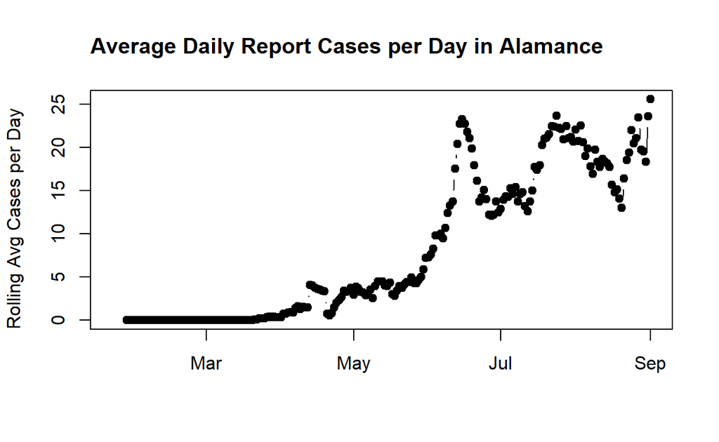

```r
alamance_complete <- alamance_cases[, avg_daily_cases_per_100k := cases_daily/(alamance_population/100000)] %>%
  .[,avg_daily_cases_per_100k_rolling := zoo::rollmean(avg_daily_cases_per_100k,
                                                       k = 7,
                                                       align = "right",
                                                       na.pad = TRUE)]

plot(alamance_complete[,date],
     alamance_complete[,avg_daily_cases_per_100k_rolling],
     ylab = "Rolling Avg Cases per Day",
     xlab = '', type = 'b', pch = 19,
     main = "Average Daily Report Cases per Day in Alamance", adj = 0)
```

## Generate Simulation Grid

Given the above methodology, we can create a simulation grid which represent the different scenarios for which we wish to solve.

```r
gathering_size <- seq(10,50,5)
cases_per_100 <- 1:25

sim_options <- tidyr::crossing(gathering_size,
                               cases_per_100,
                               pop = alamance_population)
```

We can then use our created functions to iterate over this grid of scenarios.

```r
results <-purrr::pmap_dbl(.l = list(..1=sim_options$gathering_size,
                                    ..2=sim_options$cases_per_100,
                                    ..3 = sim_options$pop),
                          ~calc_risk(I = mean(
                            run_infections_simulation(n_people = 10000,
                                                    contact_rate_per_day = ..2,
                                                    positive_test_rate = .05,
                                                    infectious_period =
                                                      12)[["average_q"]])*..3/100000,
                            n = ..1, pop = ..3))
```

Put the outputs together:

```r
output <- tibble::tibble(
  gathering_size = sim_options$gathering_size,
  cases_per_100 = sim_options$cases_per_100,
  prob_someone_having_covid = results
)
```

```r
DT::datatable(output,
              colnames = c("Contacts per Day", "Cases per 100k", "P(Covid Contact) %"),
              rownames = FALSE)
```

| Contacts per Day | Cases per 100k | P(Covid Contact) % |
| --- | --- | --- |
| 10 | 1 | 0.6 |
| 10 | 2 | 1.2 |
| 10 | 3 | 1.8 |
| 10 | 4 | 2.4 |
| 10 | 5 | 3 |
| 10 | 6 | 3.6 |
| 10 | 7 | 4.1 |
| 10 | 8 | 4.7 |
| 10 | 9 | 5.3 |
| 10 | 10 | 5.9 |

[output cut: 215 more lines]